# Sentiment Analysis for Reddit users on Nuclar Energy

When Enrico Fermi built the first nuclear reactor at the University of Chicago, it was still an elusive technology that promissed a lot. After the World-War II, and the dropping og the nuclear bombs over Hiroshima and Nagasaki, the world was shocked at the destructive power of atomic energy. This hoever, did not prevent governments to engage in masive Nuclear power-plant project in the hope of electrifying their economies.

```python
import pandas as pd
import datetime as dt
import matplotlib.pyplot as plt
from nltk.sentiment import SentimentIntensityAnalyzer
import requests
import time

import praw
from datetime import datetime, timedelta
import nltk
from nltk.tokenize import word_tokenize
from nltk.corpus import stopwords
import string
```

It took me a while to set up the reddit app. It was also not properly working at the beginnig.

```python
reddit = praw.Reddit(
    client_id="NQryrzEJMx9V_p7_7nTO-g",
    client_secret="prCOqfgHb8QaRIML3IQzmJYXDx89YA",
    user_agent="EUgoNuclear/1.0 (by /u/Cap12345678)",
    username="u/Cap12345678"
)
```

```python
subreddits = ['NuclearEnergy', 'nuclear', 'NuclearPower', 'environment']
posts = []

for subreddit_name in subreddits:
    subreddit = reddit.subreddit(subreddit_name)
    for submission in subreddit.top(limit=100000):
        posts.append([submission.title, submission.selftext, submission.score, submission.created_utc])

df = pd.DataFrame(posts, columns=['title', 'content', 'score', 'timestamp'])
df['timestamp'] = pd.to_datetime(df['timestamp'], unit='s')
df.to_csv('reddit_nuclear_energy.csv')
```

```python
df
```

|  | title | content | score | timestamp |
| --- | --- | --- | --- | --- |
| 0 | There has been a lot of fear mongering about N... |  | 71 | 2019-12-20 16:47:45 |
| 1 | I'm 40% Nuclear! |  | 63 | 2020-12-19 19:41:32 |
| 2 | u/govschwarzenegger comes out for nuclear power |  | 63 | 2020-09-01 01:07:27 |
| 3 | Nuclear Energy is key to providing a safe and ... |  | 50 | 2019-12-20 02:12:18 |
| 4 | This Is the most complicated meme i ever done |  | 44 | 2021-04-28 06:48:45 |
| ... | ... | ... | ... | ... |
| 3961 | Supreme Court deals blow to oil companies by t... |  | 2669 | 2023-04-24 18:27:16 |
| 3962 | James Cameron, the director of “Avatar” and “T... |  | 2642 | 2023-06-11 04:38:23 |
| 3963 | Land temperatures in Spain surpass 60C as dead... |  | 2315 | 2023-07-13 21:24:37 |
| 3964 | ‘OilyFans’ billboards show BP chief executive ... |  | 2295 | 2023-07-24 10:51:43 |
| 3965 | The temperature is too damn high and our bodie... |  | 2264 | 2023-07-08 10:22:54 |

3966 rows × 4 columns

```python
from textblob import TextBlob
import matplotlib.pyplot as plt

def classify_sentiment(text):
    sentiment_score = TextBlob(str(text)).sentiment.polarity
    if sentiment_score > 0:
        return 'positive'
    elif sentiment_score < 0:
        return 'negative'
    else:
        return 'neutral'

df['sentiment_category'] = df['content'].apply(classify_sentiment)
```

```python
positive_trend = df[df['sentiment_category'] == 'positive'].resample('M', on='timestamp').size()
neutral_trend = df[df['sentiment_category'] == 'neutral'].resample('M', on='timestamp').size()
negative_trend = df[df['sentiment_category'] == 'negative'].resample('M', on='timestamp').size()
```

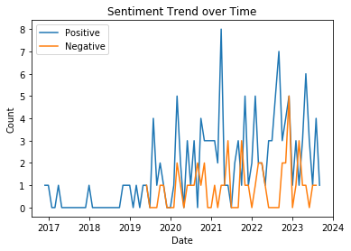

```python
plt.plot(positive_trend.index, positive_trend.values, label='Positive')
#plt.plot(neutral_trend.index, neutral_trend.values, label='Neutral')
plt.plot(negative_trend.index, negative_trend.values, label='Negative')
plt.xlabel('Date')
plt.ylabel('Count')
plt.title('Sentiment Trend over Time')
plt.legend()
plt.show()
```

```python
#Bag of Words
from sklearn.feature_extraction.text import CountVectorizer
from sklearn.model_selection import train_test_split

X = df['title']
y = df['score']

X_train, X_test, y_train, y_test = train_test_split(X, y, test_size=0.2, random_state=42)

vectorizer = CountVectorizer()
X_train_counts = vectorizer.fit_transform(X_train)
X_test_counts = vectorizer.transform(X_test)
```

```python
#Step 5: Training Decision Tree Regressor

from sklearn.tree import DecisionTreeRegressor
from sklearn.metrics import mean_squared_error

hyperparameters = [{'max_depth': 3}, {'max_depth': 5}, {'max_depth': 10}]

for params in hyperparameters:
    regressor = DecisionTreeRegressor(**params)
    regressor.fit(X_train_counts, y_train)

    y_pred_train = regressor.predict(X_train_counts)
    y_pred_test = regressor.predict(X_test_counts)

    print(f"Hyperparameters: {params}")
    print(f"Training MSE: {mean_squared_error(y_train, y_pred_train)}")
    print(f"Test MSE: {mean_squared_error(y_test, y_pred_test)}\n")
```

```
Hyperparameters: {'max_depth': 3}
Training MSE: 9868274.203141604
Test MSE: 10112397.425794654

Hyperparameters: {'max_depth': 5}
Training MSE: 7814769.903732027
Test MSE: 10064091.078317411

Hyperparameters: {'max_depth': 10}
Training MSE: 5139477.662674983
Test MSE: 10308380.128797982
```

```python
'''PF1:chapter 3 slides'''

%matplotlib inline
import numpy as np
import pandas as pd
import matplotlib.pyplot as plt
import datetime as dt
import pandas_datareader.data as web
import os
import yfinance as yf
yf.pdr_override()
plt.rc('figure', figsize=(10, 6))
pd.options.display.max_rows = 20
np.set_printoptions(precision=4, suppress=True)
```

```python
import yfinance as yf
import pandas as pd

# List of ticker symbols
'''NextEra Energy, Inc. (NEE), Cameco Corporation, Energy Fuels Inc., Uranium Energy Corp.,
Public Service Enterprise Group Incorporated (PEG), Entergy Corporation (ETR), and Denison Mines Corp.'''
tickers = ['NEE', 'CCJ', 'UUUU', 'UEC', 'PEG', 'ETR', 'DNN']

# Dates
start_date = '2013-01-01'
end_date = '2023-08-11'

# Create an empty dictionary to store the dataframe
stock_data = {}
```

```python
for ticker in tickers:
    # Download data
    data = yf.download(ticker, start=start_date, end=end_date)

    # Store in dictionary
    stock_data[ticker] = data
```

```
[*********************100%***********************]  1 of 1 completed
[*********************100%***********************]  1 of 1 completed
[*********************100%***********************]  1 of 1 completed
[*********************100%***********************]  1 of 1 completed
[*********************100%***********************]  1 of 1 completed
[*********************100%***********************]  1 of 1 completed
[*********************100%***********************]  1 of 1 completed
```

```python
# Print the number of non-missing observations
for ticker, data in stock_data.items():
    print(f"{ticker}: {data['Close'].count()} non-missing observations")
```

```
NEE: 2670 non-missing observations
CCJ: 2670 non-missing observations
UUUU: 2670 non-missing observations
UEC: 2670 non-missing observations
PEG: 2670 non-missing observations
ETR: 2670 non-missing observations
DNN: 2670 non-missing observations
```

```python
print(stock_data)
```

[output not shown]

[output cut: 44 more lines]

[output not shown]

```python
for stock in stock_data:
    print(stock, stock_data[stock].count())
```

```
NEE Open         2670
High         2670
Low          2670
Close        2670
Adj Close    2670
Volume       2670
dtype: int64
CCJ Open         2670
High         2670
Low          2670
Close        2670
Adj Close    2670
Volume       2670
dtype: int64
UUUU Open         2670
High         2670
Low          2670
Close        2670
Adj Close    2670
Volume       2670
dtype: int64
UEC Open         2670
High         2670
Low          2670
Close        2670
Adj Close    2670
Volume       2670
dtype: int64
PEG Open         2670
High         2670
Low          2670
Close        2670
Adj Close    2670
Volume       2670
dtype: int64
ETR Open         2670
High         2670
Low          2670
Close        2670
Adj Close    2670
Volume       2670
dtype: int64
DNN Open         2670
High         2670
Low          2670
Close        2670
Adj Close    2670
Volume       2670
dtype: int64
```

```python
# Create an empty DataFrame to store the rescaled adjusted closing prices
rescaled_data = pd.DataFrame()

for ticker, data in stock_data.items():
    # Find the price at the end of 2021
    end_of_2021_price = data['Adj Close']['2021-12-31']

    # Rescale the adjusted closing prices
    rescaled_adjusted_close = data['Adj Close'] / end_of_2021_price

    # Add to the rescaled_data DataFrame
    rescaled_data[ticker] = rescaled_adjusted_close

# Filter the data for the period from 2022 to 2023
rescaled_data_2022_2023 = rescaled_data['2022-01-01':'2023-08-11']
```

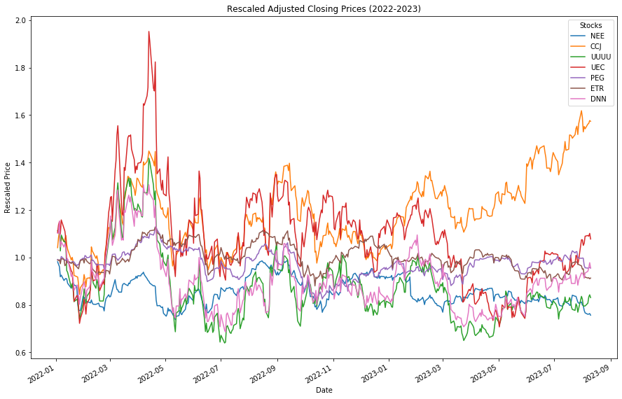

```python
# Plot the rescaled adjusted closing prices
rescaled_data_2022_2023.plot(figsize=(15,10), title="Rescaled Adjusted Closing Prices (2022-2023)")
plt.xlabel("Date")
plt.ylabel("Rescaled Price")
plt.legend(title="Stocks")
plt.show()
```

```python
# Create a new DataFrame to store the calculated values
calculated_data = pd.DataFrame()

for ticker, data in stock_data.items():
    # Calculate the daily arithmetic returns
    data['Daily Return'] = data['Adj Close'].pct_change()

    # Calculate the intra-day volatility
    data['Intra-Day Volatility'] = (data['High'] - data['Low']) / data['Open']

    # Select only the relevant columns
    calculated_data[ticker + '_Return'] = data['Daily Return']
    calculated_data[ticker + '_Volatility'] = data['Intra-Day Volatility']
```

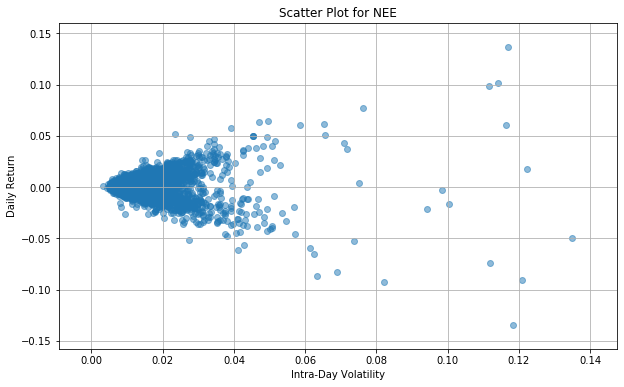

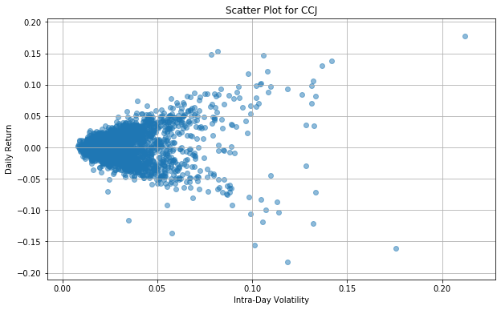

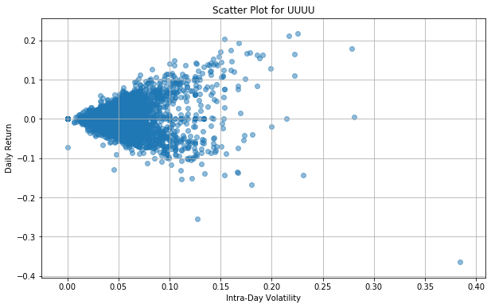

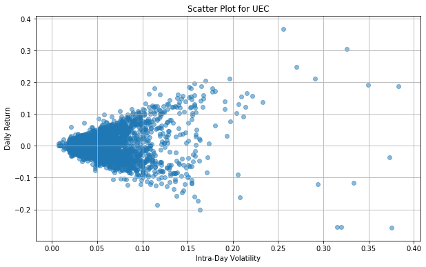

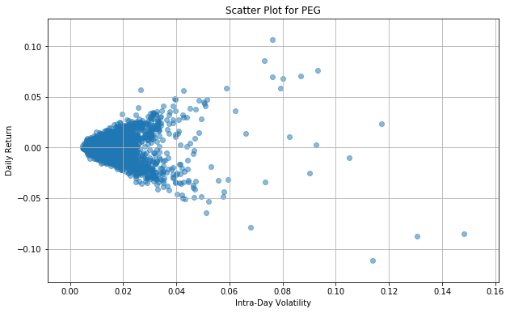

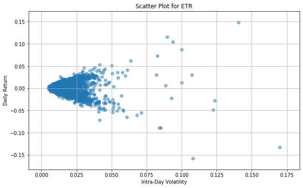

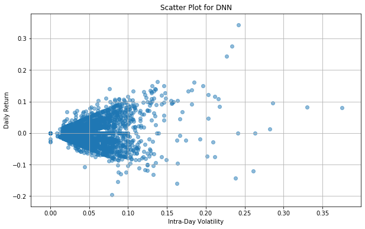

```python
# Loop through the tickers and create scatter plots
for ticker in tickers:
    plt.figure(figsize=(10,6))
    plt.scatter(calculated_data[ticker + '_Volatility'], calculated_data[ticker + '_Return'], alpha=0.5)
    plt.title(f'Scatter Plot for {ticker}')
    plt.xlabel('Intra-Day Volatility')
    plt.ylabel('Daily Return')
    plt.grid(True)
    plt.show()
```

```python
# Calculate the equal-weighted portfolio value
portfolio_value = rescaled_data.sum(axis=1) / len(tickers)

# Filter the data for the period from 2021 to 2023
portfolio_value_2022_2023 = portfolio_value['2022-01-01':'2023-08-11']
```

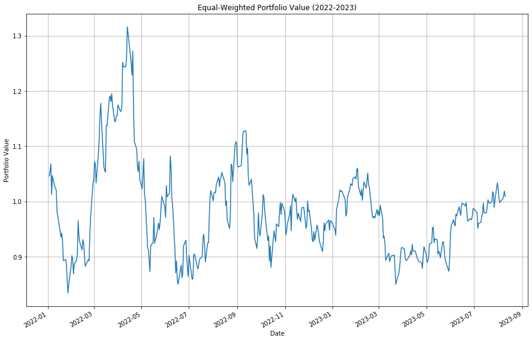

```python
plt.figure(figsize=(15,10))
portfolio_value_2022_2023.plot(title="Equal-Weighted Portfolio Value (2022-2023)")
plt.xlabel("Date")
plt.ylabel("Portfolio Value")
plt.grid(True)
plt.show()
```

Analyzing stock performance over a long period of time can provide valuable insights, especially if one is looking for any discontinuities or abnormal behavior. A discontinuity could be the result of significant events like mergers, acquisitions, corporate restructuring, financial crises, or major market news that affect the stock price.

Here, I plot the equal-weighted portfolio value from 2013 to 2023 with an emphasis on February 2022 to visually inspect any discontinuity.

Equal-weighted portfolio value from 2013 to 2023, with a vertical dashed line at the end of February 2022 is shown below. Significant changes in sentiment can be noticed as of early 2020, but this could mostly be attributed to the COVID shutdown, and major energy portfolio readjustments due to lockdown and grounding of airlines. A second change, however is noticed just prior to Russias invasion of Ukraine, and this could be interpreted as a resilience in sentiment, despite Russias repeated to nuclear threats, and its assaults in and near Zaporizhzhia Nuclear Power Plant.

Visual inspection provides an initial understanding but might not be conclusive. So I might need to apply statistical tests (RDD, for example).

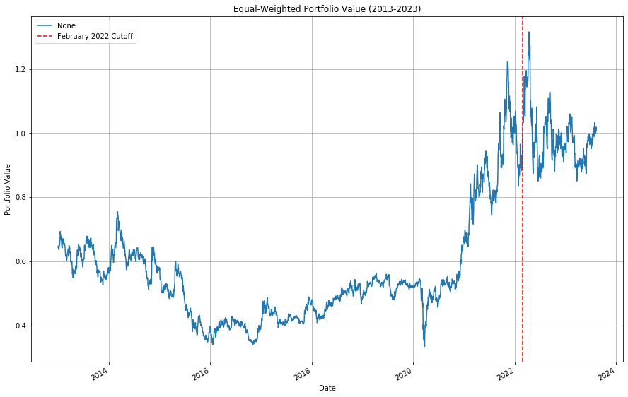

```python
plt.figure(figsize=(15,10))
portfolio_value.plot(title="Equal-Weighted Portfolio Value (2013-2023)")
plt.axvline(x='2022-02-28', color='red', linestyle='--', label='February 2022 Cutoff')
plt.xlabel("Date")
plt.ylabel("Portfolio Value")
plt.legend()
plt.grid(True)
plt.show()
```

# Regression Discontinuity Design

```python
import statsmodels.api as sm
import statsmodels.formula.api as smf
import numpy as np
import pandas as pd
```

```python
# Assume you have a DataFrame 'df' with columns 'outcome', 'treatment', 'running_var'
# 'outcome' is the adjusted price (portfolio value)
# 'treatment' is the binary treatment indicator (0 or 1 for war in Ukraie)
# 'running_var' is the running variable used to define the threshold

# Treatment start date
treatment_start_date = '2022-02-24'

# Create DataFrame
rdd_data = pd.DataFrame({
    'outcome': portfolio_value, # Portfolio performance
    'running_var': portfolio_value.index.to_julian_date(),
})

# Assign the treatment based on the treatment start date
rdd_data['treatment'] = (rdd_data.index >= treatment_start_date).astype(int)

# Filter the DataFrame to the relevant period
rdd_data = rdd_data['2013-01-01':'2023-08-11']

# Print the first few rows to check
print(rdd_data.head())
print(rdd_data.tail())
```

```
             outcome  running_var  treatment
Date
2013-01-02  0.642914    2456294.5          0
2013-01-03  0.648135    2456295.5          0
2013-01-04  0.644014    2456296.5          0
2013-01-07  0.636835    2456299.5          0
2013-01-08  0.639523    2456300.5          0
             outcome  running_var  treatment
Date
2023-08-04  1.000220    2460160.5          1
2023-08-07  1.004587    2460163.5          1
2023-08-08  1.010966    2460164.5          1
2023-08-09  1.018779    2460165.5          1
2023-08-10  1.009116    2460166.5          1
```

```python
import seaborn as sns

# Fit the RDD model
```

```python
# Fit the RDD model
# Define the threshold value for the running variable
threshold_value = pd.Timestamp(treatment_start_date).to_julian_date()

# Create an indicator for observations to the right of the threshold
rdd_data['threshold_indicator'] = (rdd_data['running_var'] > threshold_value).astype(int)

# Interact the treatment indicator with the threshold indicator
rdd_data['interaction'] = rdd_data['treatment'] * rdd_data['threshold_indicator']

# Define the regression model including the interaction term
model_formula = "outcome ~ treatment + threshold_indicator + interaction + running_var"

# Fit the regression model using Ordinary Least Squares (OLS)
result = smf.ols(formula=model_formula, data=rdd_data).fit()
```

```python
# Create a DataFrame with the running variable and predicted outcome
plot_data = pd.DataFrame({
    'running_var': rdd_data['running_var'],
    'predicted_outcome': result.predict(rdd_data),
})
```

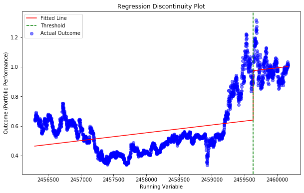

```python
# Plot the actual outcome
plt.scatter(rdd_data['running_var'], rdd_data['outcome'], color='blue', alpha=0.5, label='Actual Outcome')
# Plot the predicted outcome (fitted lines)
sns.lineplot(x='running_var', y='predicted_outcome', data=plot_data, color='red', label='Fitted Line')

# Draw the threshold line
plt.axvline(x=pd.Timestamp(treatment_start_date).to_julian_date(), color='green', linestyle='--', label='Threshold')

# Labels and legend
plt.title('Regression Discontinuity Plot')
plt.xlabel('Running Variable')
plt.ylabel('Outcome (Portfolio Performance)')
plt.legend()
plt.show()
```

```python
import statsmodels.api as sm
from statsmodels.sandbox.regression.gmm import IV2SLS



# Define the treatment based on the threshold
rdd_data['treatment'] = (rdd_data['running_var'] >= threshold_value).astype(int)

# Add a constant term
rdd_data['const'] = 1

# Define endogenous variable (outcome)
endog = rdd_data['outcome']

# Define exogenous variables
exog = rdd_data[['const', 'running_var', 'treatment']]

# Define the instrument (just the running variable in this simplified model)
instrument = rdd_data[['const', 'running_var']]

# Perform the 2SLS regression
model_2sls = IV2SLS(endog, exog, instrument=instrument).fit()
```

```python
# Print the summary
print(model_2sls.summary())
```

```
                          IV2SLS Regression Results
==============================================================================
Dep. Variable:                outcome   R-squared:                       0.426
Model:                         IV2SLS   Adj. R-squared:                  0.426
Method:                     Two Stage   F-statistic:                    -86.19
                        Least Squares   Prob (F-statistic):               1.00
Date:                Tue, 15 Aug 2023
Time:                        13:11:33
No. Observations:                2670
Df Residuals:                    2667
Df Model:                           2
===============================================================================
                  coef    std err          t      P>|t|      [0.025      0.975]
-------------------------------------------------------------------------------
const          -5.4208        nan        nan        nan         nan         nan
running_var   2.42e-06      0.005      0.000      1.000      -0.011       0.011
treatment       0.6075        nan        nan        nan         nan         nan
==============================================================================
Omnibus:                      643.385   Durbin-Watson:                   0.013
Prob(Omnibus):                  0.000   Jarque-Bera (JB):             1420.676
Skew:                           1.366   Prob(JB):                    3.19e-309
Kurtosis:                       5.304   Cond. No.                     6.73e+09
==============================================================================
```

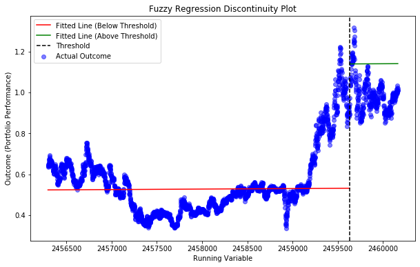

```python
# Predicted outcome based on the 2SLS fit
rdd_data['predicted_outcome'] = model_2sls.predict(exog)

# Separate data above and below the threshold
below_threshold = rdd_data[rdd_data['running_var'] < threshold_value]
above_threshold = rdd_data[rdd_data['running_var'] >= threshold_value]

# Plot actual outcomes
plt.scatter(rdd_data['running_var'], rdd_data['outcome'], color='blue', alpha=0.5, label='Actual Outcome')

# Plot fitted lines for below and above the threshold
plt.plot(below_threshold['running_var'], below_threshold['predicted_outcome'], color='red', label='Fitted Line (Below Threshold)')
plt.plot(above_threshold['running_var'], above_threshold['predicted_outcome'], color='green', label='Fitted Line (Above Threshold)')

# Draw the threshold line
plt.axvline(x=threshold_value, color='black', linestyle='--', label='Threshold')

# Labels and legend
plt.title('Fuzzy Regression Discontinuity Plot')
plt.xlabel('Running Variable')
plt.ylabel('Outcome (Portfolio Performance)')
plt.legend()
plt.show()
```